# EEMB247/BMSE247: Computer lab 4: Local Stability Analysis, Separation of Time Scales, plus R tutorial on the Basics of graphing in R

## R tutorial, Part 4: The basics of plotting in R

*Portions of this lesson were adopted from a Software Carpentry tutorial by Mark Wilber.*

In the R tutorial in Computer Lab 3, we learned how to use the read.csv command to load data into R:

```r
frog <- read.csv("../Lab3/frog_data.csv", header = TRUE)
```

You can plot the whole data frame using the command:

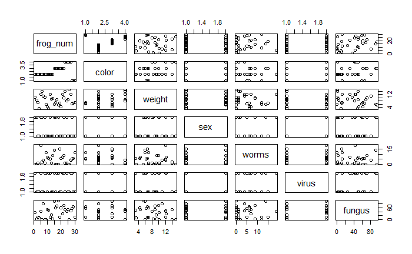

```r
plot(frog)
```

R will plot each variable against every other variable, whether or not that makes sense.

There are pros and cons to plotting the entire dataframe.

Though these plots are messy, tiny, and potentially meaningless, they allow you to can very quickly assess your data:

- are there wild outliers that might be typos? No.
- are all your variables coded correctly - typos, number vs. factor? Looks like it.
- are you excited about any of those patterns?

> Tip: In some R GUIs (RStudio, R Console SDI…) the plot window may be small, making multi-faceted figure like this one hard to interpret. Try the following to open whole new windows for your figure:

> *windows(), x11(), or quartz() in windows, unix, or Mac respectively.* any of these can be closed to return to the GUI and default graphics settings using dev.off().

Scientists tend to make two or three types of plots very frequently: scatter plots, histograms, and boxplots. For the frog data, let’s make a scatter plot of worms and fungus.

### 1. Scatter Plot

This time, rather than plotting the whole data frame, we will plot only those variables for which we want to see the relationship.

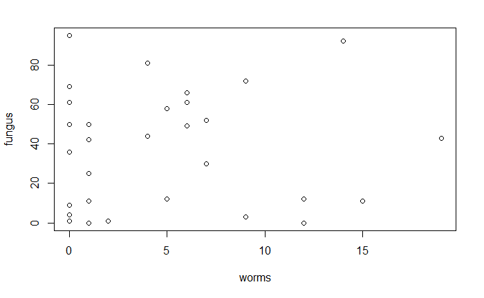

```r
plot(fungus~worms,data=frog)
```

`plot` takes three arguments to make a very basic plot:

- The third, ‘data’ specifies the data frame from which which you are drawing data.
- The first two are the two variables you want to examine. If they are related by `~`, it means something like “fungus with respect to worms”. This will put fungus on the y axis and worms on the x-axis.
- The alternative syntax for this is: `plot(worms,fungus,data=frog)`. If the first two variables are separated by a comma, R will plot the first variable (worms) on the x-axis and the second variable (fungus) on the y-axis.

#### Adding a little style to plots

This figure looks OK, certainly useful for exploratory analyses and proofing your data. But lets add a couple arguments to the `plot()` function to enhance the figure. Here’s a few we like to use when making basic figures for presentation:

`xlab` and `ylab` allow you to specify character strings to change your axis labels; for example, to add your measurement units.  
`pch` lets you set the shape of data points (google “pch r” to see the options)  
`cex` scales text and symbols relative to default.  
`col` sets colors, using words is easiest  
specifying `.axis` or `.lab` after these allows you to control the size or color of the axis and labels  
`xlim` or `ylim` allow you to specify the ranges of your axes  
`type = "l"` (lines) will connect the points in order with lines, without point markers  
`type = "b"` (both) will connect the points in order with lines, and include point markers.

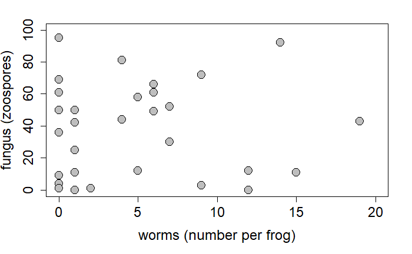

```r
plot(fungus~worms, data=frog,
     ylab="fungus (zoospores)", xlab="worms (number per frog)",
     cex=2, cex.axis=1.5, cex.lab=1.5,
     pch=21,
     col="black", bg="grey",
     xlim=c(0,20), ylim=c(0,100))
```

### 2. Histograms

You can make histograms using the `hist` command:

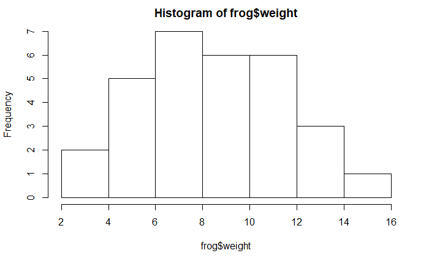

```r
hist(frog$weight)
```

A few notes about `hist()`:

- For whatever reason, `hist()` does not take a data argument like `plot()` does. You must specify the vector as a part of the data frame using the $: `frog$weight`
- You can alter many characteristics of the plot, using arguments such as `xlab`, `ylab`, `col`, `main`.
- R automatically sets the breaks; you may adjust them using the breaks= argument, which accepts a vector, e.g.:

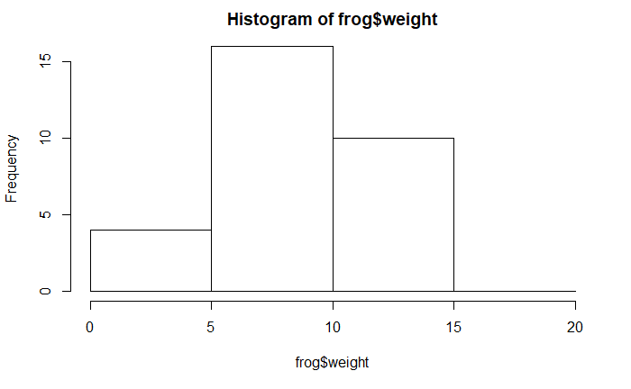

```r
hist(frog$weight, breaks=c(0,5,10,15,20))
```

or

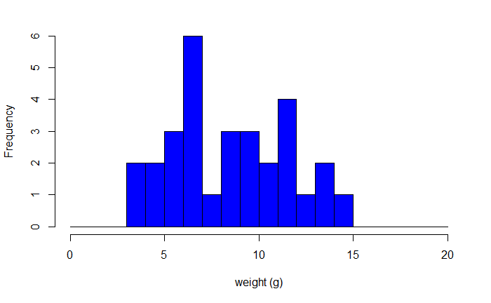

```r
hist(frog$weight, breaks=seq(0,20,1), col="blue", xlab = "weight (g)", main="")
```

### 3. Boxplots

You can make boxplots using the `boxplot` command:

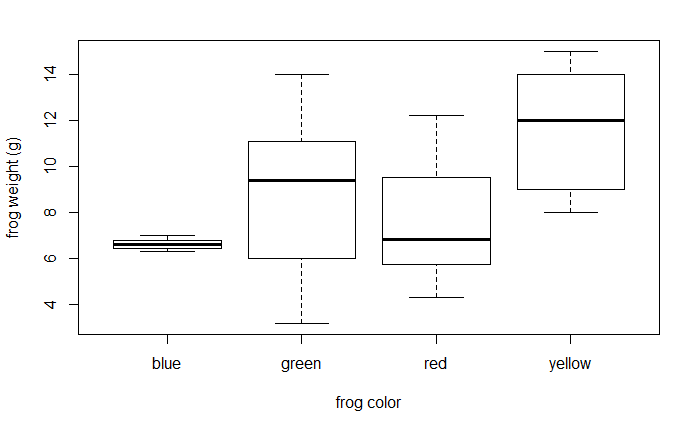

```r
boxplot(weight~color, data =frog,
    xlab="frog color", ylab="frog weight (g)")
```

You have to be careful in intepretting boxplots. In R the default is: “The bottom and top of the box are always the 25th and 75th percentile (the lower and upper quartiles, respectively), and the band near the middle of the box is always the 50th percentile (the median). But the ends of the whiskers can represent several possible alternative values.”

In R’s default boxplot{graphics} code,

upper whisker = min(max(x), Q_3 + 1.5 * IQR)  
lower whisker = max(min(x), Q_1 – 1.5 * IQR)

where IQR = Q_3 – Q_1, the box length.

So the upper whisker is located at the *smaller* of the maximum x value and Q_3 + 1.5 IQR,  
whereas the lower whisker is located at the *larger* of the smallest x value and Q_1 – 1.5 IQR.

### 4. Saving/Exporting Figures

If you are going to use a figure in a presentation or paper, you could copy and paste it, but saving/exporting it is programmable and reproducible, and allows you to control size, resolution, and file type.

To write a figure to a file, you:

1. open a plotting ‘device’ and specify the file path
2. run the plot function
3. close the device

Like this:

```r
jpeg("Figure_1.jpg")         # you can add a path to this
plot(fungus~worms, data=frog,
     ylab="fungus (zoospores)", xlab="worms (number per frog)",
     cex=2, cex.axis=1.5, cex.lab=1.5,
     pch=21,
     col="black", bg="grey",
     xlim=c(0,20), ylim=c(0,100))
dev.off()
```

You won’t see the plot produced by this code, until you open the file you just created.

## ggplot

To run this portion of the tutorial, you need to have installed and loaded the package `ggplot2`.

```r
library("ggplot2")
```

Other packages that will enhance ggplots are: `ggthemes`, `gridExtra`, `devtools`, `colorbrewer` and many, many others.

*Portions of this lesson were adopted from a Software Carpentry tutorial by Mark Wilber.*

### What is ggplot?

ggplot is an alternative to the “base” R graphics.  
* The “gg” stands for grammar of graphics * A syntax for making plots and figures. * Defines components of a figure. * Coherent, consistent syntax for a range of plotting.

Compare to “base” graphics:

`plot(fungus~worms, data=frog)`

vs.

`ggplot(data=frog, aes(x=worms, y=fungus)) + geom_point()`

### Parts of a ggplot plot:

There are several essential parts of any plot, and in `ggplot2`, they are:

1. the function: `ggplot()`
2. the arguments:
- data
- aes
- geom
- stats
- facets
- scales
- theme
- …and others

We won’t cover these in much depth, but if you are comfortable with what we show you today, exploring the vast functionality of geom, stats, scales, and theme should be a pleasure.

#### `ggplot()`

Some people like to assign (<-) their plot function to a variable, like this:

`myplot<-ggplot(...)`

#### `data`

- This is the data you want to plot
- Must be a data.frame

For this lesson, we are going to look at the `frog` data set.

Let’s build a scatter plot of worms and fungus

`myplot<-ggplot(data=frog... )`

#### `aes`

For **aesthetics**.

How your data are to be visually represented. One of your variables will be your independent (x) variable, another will be your dependent (y) variable.

- some people call this mapping
- which data on the x
- which data on the y
- also: color, size, shape, transparency

Here is how to do it

```r
myplot<-ggplot(data=frog, aes(x=worms, y=fungus))
```

So far, we have told ggplot where to look for data, and how to represent that data, but not what to do with it.

#### `geom`

For geometry.

This is how we create the layer we actually see as our figure. These are the geometric objects likes points, lines, polygons, etc. that are in the plot

- geom_point()
- geom_line()
- geom_boxplot()
- geom_text()
- geom_bar()
- geom_hline()
- 25 more!

Let’s add a geom to make a scatter plot:

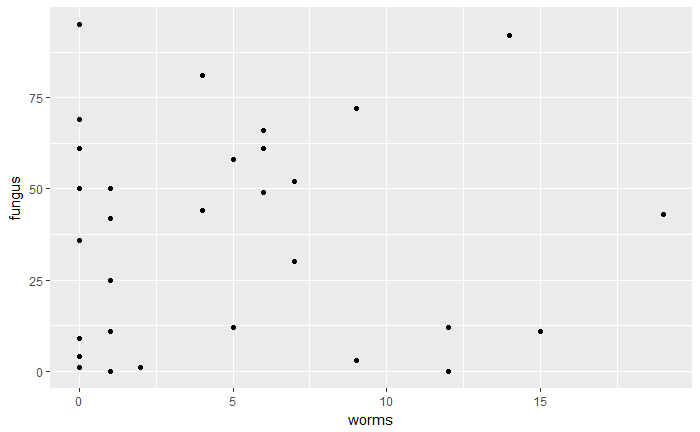

```r
myplot<-ggplot(data=frog, aes(x=worms, y=fungus))+geom_point()
myplot
```

#### Changing the aesthetics of a `geom`:

Lets increase the size of the data points…

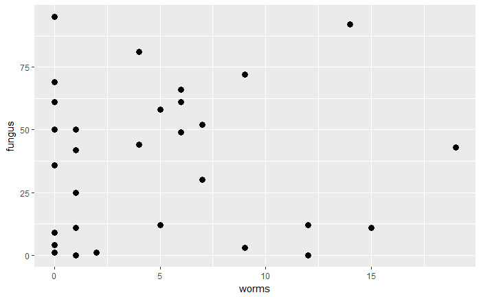

```r
ggplot(data=frog, aes(x=worms, y=fungus))+geom_point(size=3)
```

…or add some **useful** color:

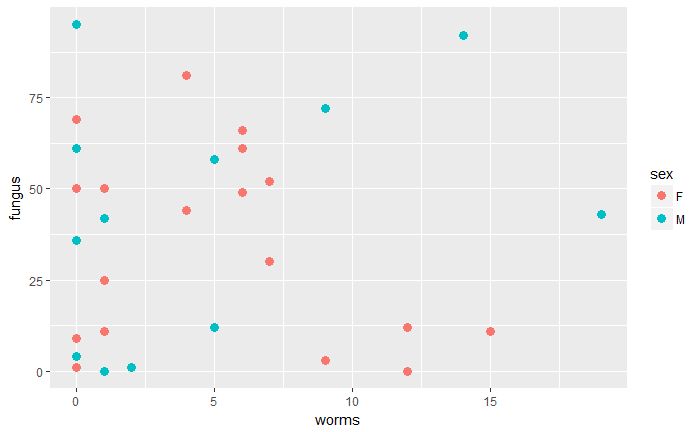

```r
ggplot(data=frog, aes(x=worms, y=fungus, color = sex))+geom_point(size=3)
```

Using color to differentiate data points with respect to sex allows us to see if there is a difference between the sexes in the relationship between worms and fungus.

If you need to use black and white, you can differentiate points by shape:

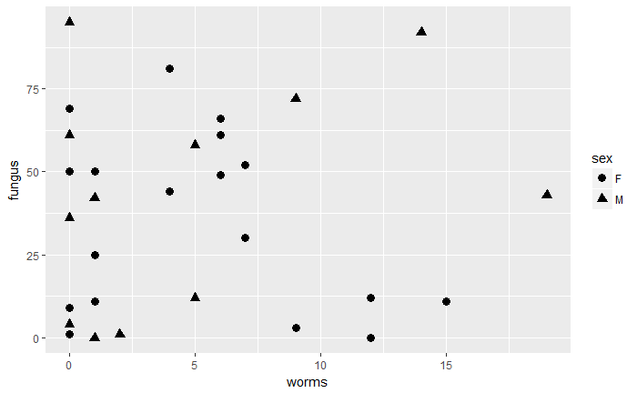

```r
ggplot(data=frog, aes(x=worms, y=fungus, shape=sex))+geom_point(size=3)
```

or, exactly the same result:

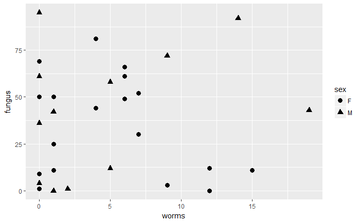

```r
ggplot(data=frog, aes(x=worms, y=fungus))+geom_point(aes(shape=sex), size=3)
```

If you don’t like those shapes, set some other shapes:

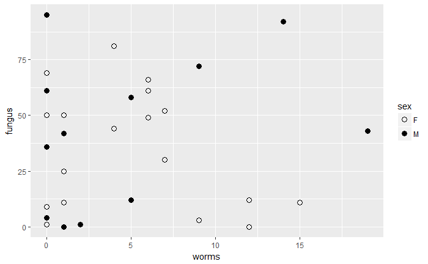

```r
ggplot(data=frog, aes(x=worms, y=fungus))+
  geom_point(aes(shape=sex), size=3)+
  scale_shape_manual(values=c(1,16))
```

Here we used a `geom_scale` to map specific point shapes onto their species values. If `aes()` maps shape or color to a grouping variable, then you can use a scale geom to set the values for your shape or color.

### 3 geoms for summarization:

**Boxplot:**

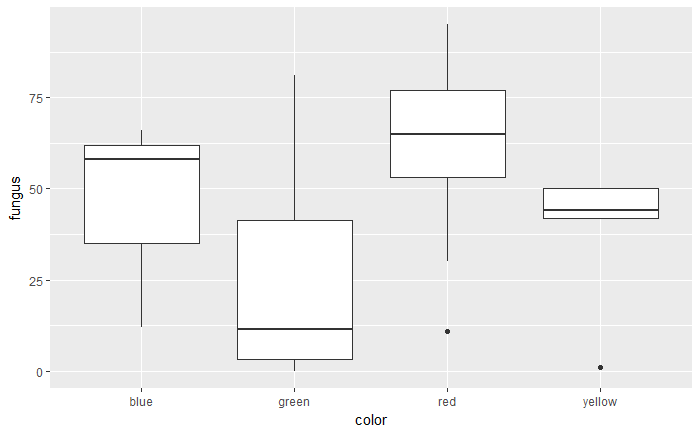

```r
ggplot(data=frog, aes(x=color, y=fungus))+
  geom_boxplot()
```

Histogram - here you need only specify one vector to be visualized in your aes():

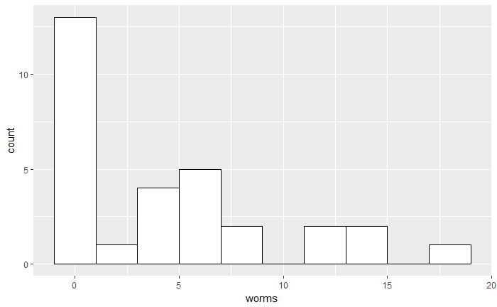

```r
ggplot(data=frog, aes(x=worms))+
  geom_histogram(binwidth=2, color="black", fill="white")
```

#### facets

Facets are panels in which plots of mapped variables are arranged according to a categorical grouping variable(s).

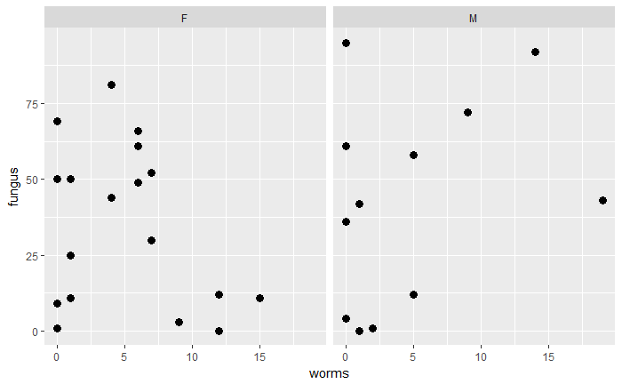

```r
ggplot(data=frog, aes(x=worms, y=fungus))+
geom_point(size=3)+
facet_grid(.~sex)
```

Specifying the group variable on the left `facet_grid(sex~.)` arranges facets in one column, on the `right facet_grid(.~sex)` in one row. You can also facet by two (or more) grouping variables. For example:

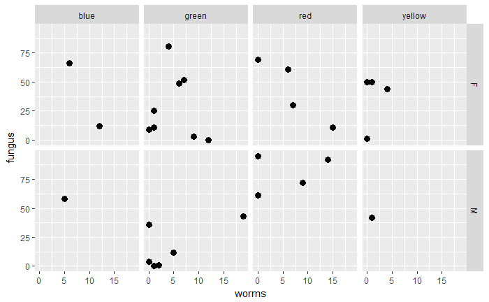

```r
ggplot(data=frog, aes(x=worms, y=fungus))+
geom_point(size=3)+
facet_grid(sex~color)
```

#### `stats`

For **statsistics**.

The `geom_boxplot()` and `geom_histogram()` are stats components, and there are a bunch. We don’t have a lot of time to cover these, but they are extremely valuable, especially if you are using ggplot2 for reporting results, rather than just exploratory plotting.

Here is another: you can add a linear fit line to a scatter plot:

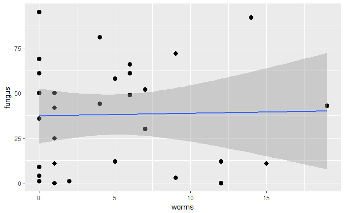

```r
ggplot(data=frog, aes(x=worms, y=fungus))+
geom_point(size=3)+
geom_smooth(method=lm)
```

#### `theme` and controlling figure appearance

Themes allow you to specify how the non-data components of your figure look, e.g. legends, axis labels, and backgrounds.

First though, there are ways to control the appearance of your data points by setting a value to them, or mapping them to a grouping variable. You can do this in the `aes()` or in the `geom`, but any character of the plot you set in `aes()` becomes a global setting for your figure. For example, if you set `aes(..., color=pink)`, then all the data in your figure will be pink, no matter what (or how many) geoms you map to the variables.

Rerun the code to see how the plot looked by default:

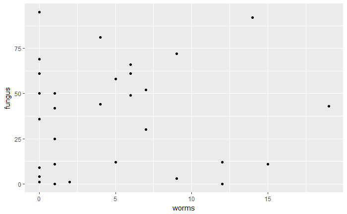

```r
ggplot(data=frog, aes(x=worms, y=fungus))+
geom_point()
```

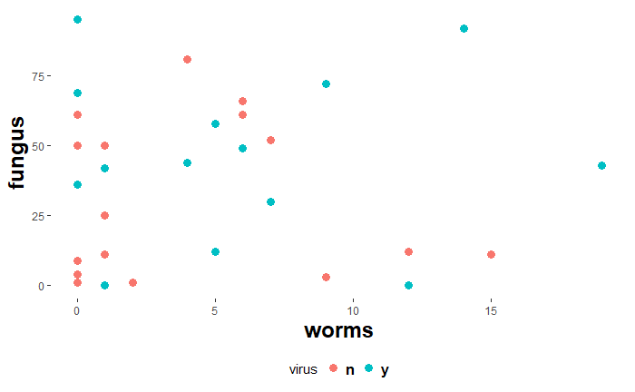

```r
ggplot(data=frog, aes(x=worms, y=fungus, color = virus))+
geom_point(size=3)+
theme(legend.key=element_rect(fill=NA),
    legend.position="bottom",
    axis.title=element_text(angle=0, size=18, face="bold"),
    legend.text=element_text(angle=0, size=12, face="bold"),
    panel.background=element_rect(fill=NA))
```

Obviously, one can really go nuts with her/his themes… and create your own customs:

```r
# install.packages("wesanderson")
library(wesanderson)
```

To see color palettes:

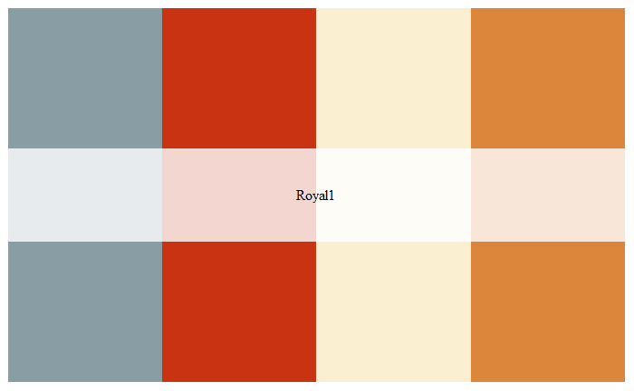

```r
wes_palette("Royal1")
```

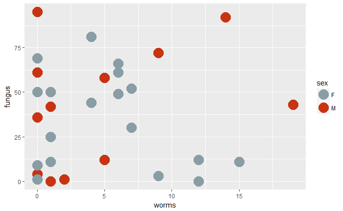

For those studying predation/medium sized mammals/trophic cascades, try:

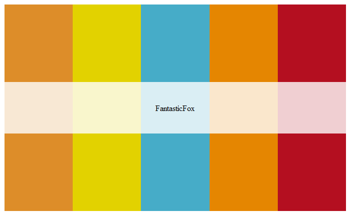

```r
wes_palette("FantasticFox")
```

…and for the marine biologists:

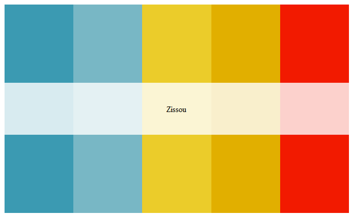

```r
wes_palette("Zissou")
```

#### Saving a ggplot figure:

You can use the same approach we showed in the basic plotting lesson, or try this:

```r
ggsave("myplot.jpg", width=8, height=8, unit="cm", dpi=300)
```

In both methods, you can save as most any image format (jpeg, TIFF, PNG, PDF, etc.), as well as specify the size and resolution (dpi) of the image.